# Stat462 hw6

Xiaoqing Ye

Question 1 (i) response variable: volume of a tree; explanatory variable: diameter of a tree.

```r
leaf=read.table("shortleaf.txt", header = T)
head(leaf)
```

```
##   Diam Vol
## 1  4.4 2.0
## 2  4.6 2.2
## 3  5.0 3.0
## 4  5.1 4.3
## 5  5.1 3.0
## 6  5.2 2.9
```

2. Comment: There is a positive relation between diameters and volumes of trees, where larger the diameter of a tree, larger the volume of a tree. It is more like a positive exponetial curve rather than a linear figure.

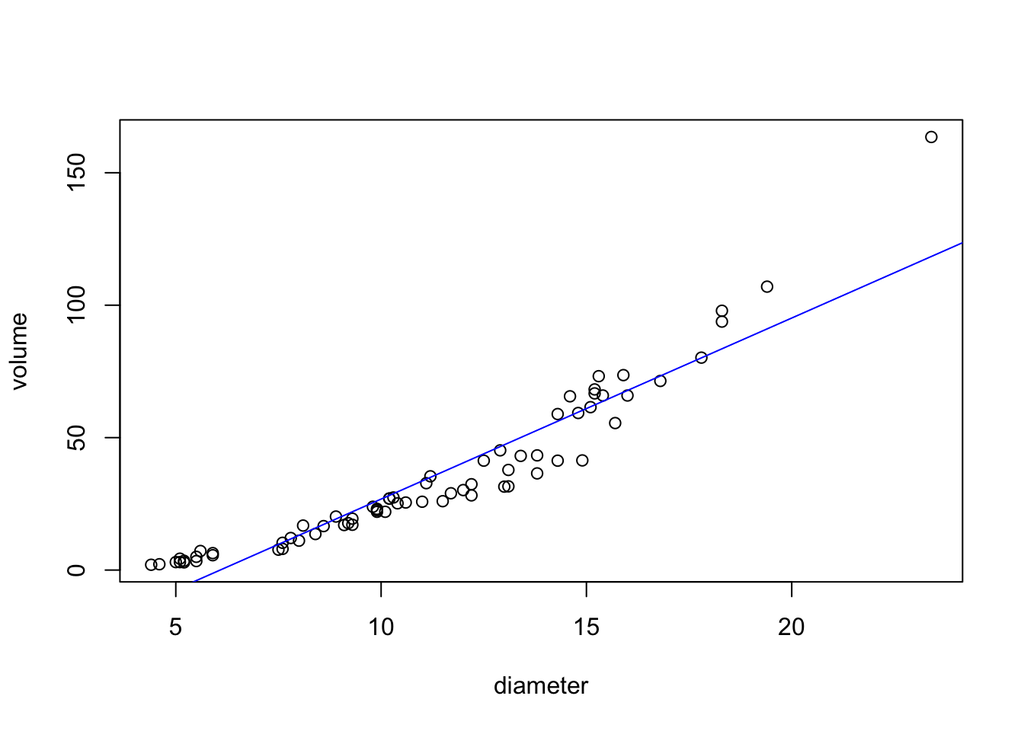

```r
plot(leaf$Diam, leaf$Vol, xlab="diameter", ylab="volume")
leaffit=lm(Vol~Diam, data=leaf)
abline(leaffit, col="blue")
```

3. $$\hat{Volume}=-41.568+6.837Diameter$$
   The intercept is -41.57, which has no physical meaning because there is not negative value of volume when the diameter is 0. It is negative just because it is based on the least squared regression line. The slope is 6.837, which means for every 1 unit of diameter increases, the volume is predicted to increase 6.837 units.

```r
summary(leaffit)
```

```
##
## Call:
## lm(formula = Vol ~ Diam, data = leaf)
##
## Residuals:
##     Min      1Q  Median      3Q     Max
## -18.899  -4.768  -1.438   6.740  45.089
##
## Coefficients:
##             Estimate Std. Error t value Pr(>|t|)
## (Intercept) -41.5681     3.4269  -12.13   <2e-16 ***
## Diam          6.8367     0.2877   23.77   <2e-16 ***
## ---
## Signif. codes:  0 '***' 0.001 '**' 0.01 '*' 0.05 '.' 0.1 ' ' 1
##
## Residual standard error: 9.875 on 68 degrees of freedom
## Multiple R-squared:  0.8926, Adjusted R-squared:  0.891
## F-statistic: 564.9 on 1 and 68 DF,  p-value: < 2.2e-16
```

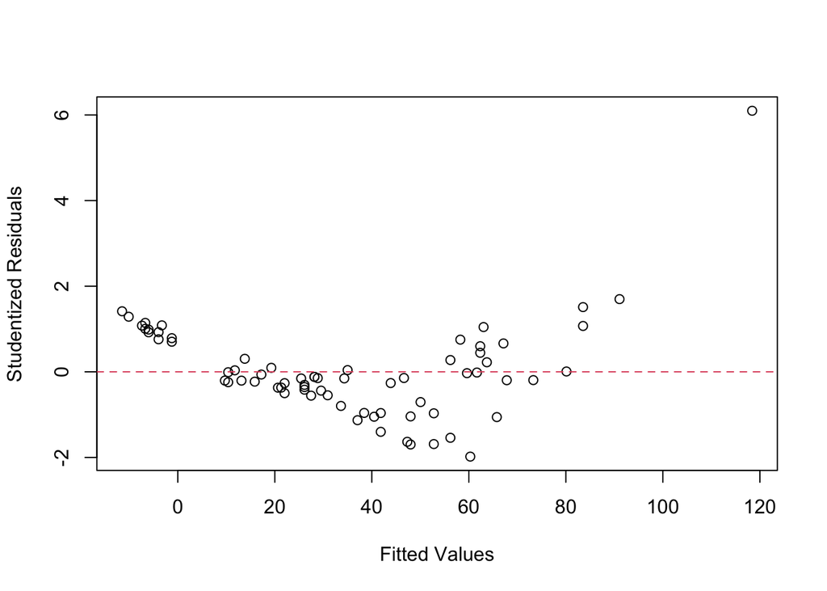

```r
library(MASS)
leaf_ri=studres(leaffit)
leaf_yihat=leaffit$fitted.values
plot(leaf_yihat,leaf_ri,ylab="Studentized Residuals",xlab="Fitted Values")
abline(h=0,col=2,lty=2)
```

Comment: From Normal Q-Q plot, it looks like the data is approximately normally distributed. Also, it looks like the distribution of residuals has a little bit thicker tails than what we would expect in a normal distribution. The middle part of the distribution is a little off the normal distribution.

But from the AD test, we found that p-value for normality is only 0.0003, which is really low. This can be due to the outlier at the right up corner.

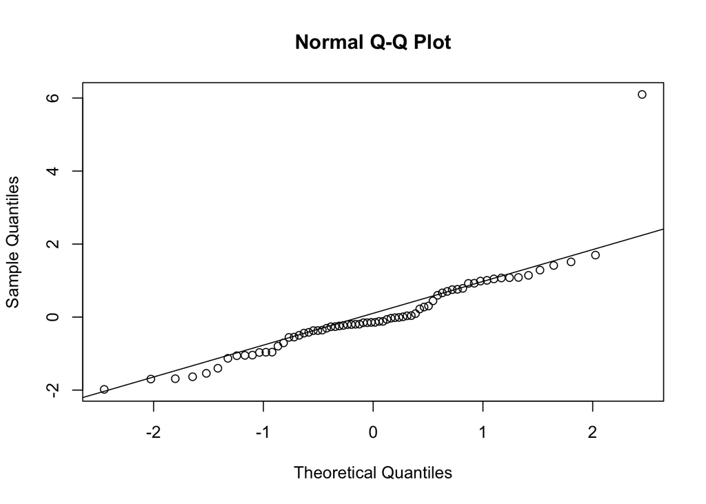

```r
qqnorm(leaf_ri)
qqline(leaf_ri)
```

```r
library(nortest)
ad.test(studres(leaffit))
```

```
##
##  Anderson-Darling normality test
##
## data:  studres(leaffit)
## A = 1.6136, p-value = 0.0003451
```

Comment: From the Leverage plot, there are two points with leverage values higher than the expected cut-off. However, there is one point that has outstandingly large leverage value.

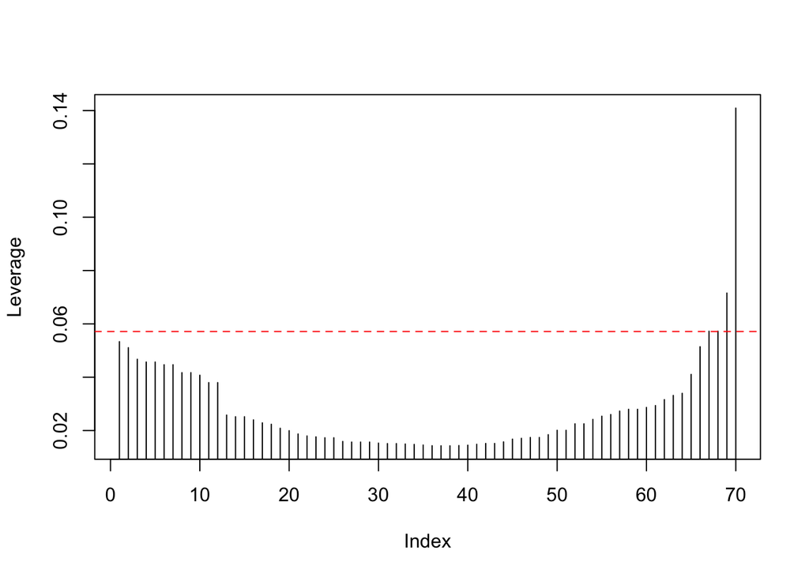

```r
plot(hatvalues(leaffit), type="h", ylab="Leverage")
n=nrow(leaf)
p=length(coefficients(leaffit))
cutLev=2*p/n
abline(h=cutLev, col="red", lty=2)
```

22. (a)(b)(c)Comment: The point with highest residual, with highest leverage and highest Cook’s distance is when “Diameter = 23.4 and Volume = 163.5”. I agree that this point has the potential to become an influential point because it is an outlier and it has high leverage point.

```r
leaf[abs(leaf_ri)==max(abs(leaf_ri)),]
```

```
##    Diam   Vol
## 70 23.4 163.5
```

```r
leaf[hatvalues(leaffit)==max(hatvalues(leaffit)),]
```

```
##    Diam   Vol
## 70 23.4 163.5
```

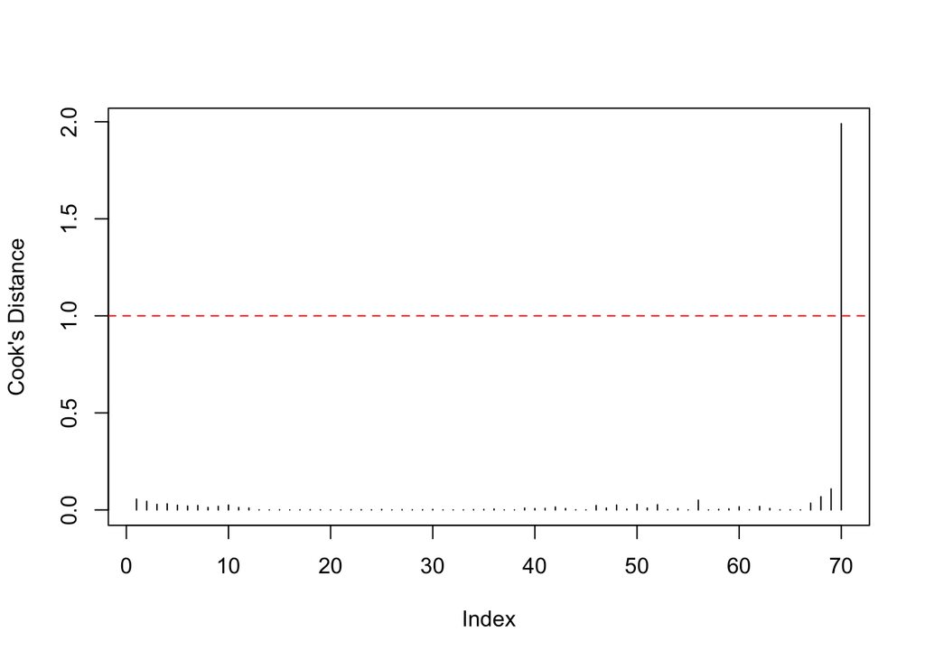

```r
plot(cooks.distance(leaffit), ylab="Cook's Distance", type="h")
abline(h=1, col="red", lty=2)
```

6. Comment: I think we can test for the transformation for response variable, explanatory variable and both when we are not sure which one will give us the best linear relation. But since there is no violation in the other assumptions: independence(trees grow independently), constant variacne(approximately increasing due to non linear), normality of the errors, we can start by transforming the predictor varible. I will choose to use the log transformation.
7. Comment: Based on the plot, there is a positive trend between log of diameters and volumes of trees, where larger the log of diameter of a tree, larger the volume of a tree. The log transformation on the explanatory variable appears to lack linearity.

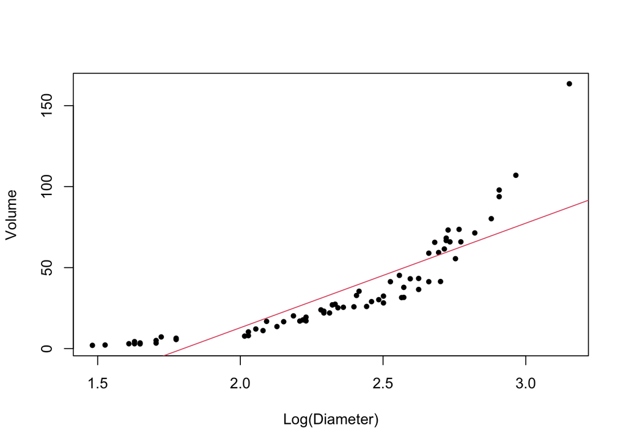

```r
leaf1=data.frame(leaf,log(leaf$Diam))
names(leaf1)=c("Diam","Vol","lnDiam")
plot(leaf1$lnDiam,leaf1$Vol,xlab="Log(Diameter)",ylab="Volume",pch=20)
leaffit1=lm(Vol~lnDiam, data=leaf1)
abline(leaffit1,col=2)
```

8. Comment: Based on the plot, there is a positive trend between diameters and log of volumes of trees, where larger the diameter of a tree, larger the log of volume of a tree. The log transformation on the reponse variable appears to lack linearity.

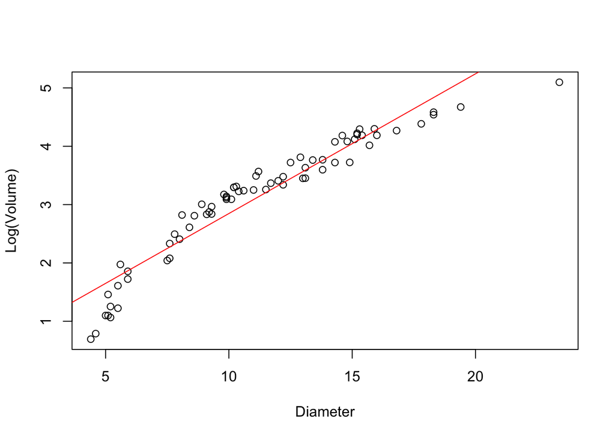

```r
leaf2=data.frame(leaf1,log(leaf$Vol))
names(leaf2)=c("Diam","Vol","lnDiam","lnVol")
plot(leaf2$Diam,leaf2$lnVol, xlab="Diameter",ylab="Log(Volume)")
leaffit2=lm(leaf2$lnVol~leaf2$Diam)
abline(leaffit2, col="red")
```

Comment: Based on the plot, there is a positive lineartrend between log of diameters and log of volumes of trees, where larger the log of diameter of a tree, larger the log of volume of a tree. The log transformation on both the explanatory variable and the reponse variable appears to have linearity.

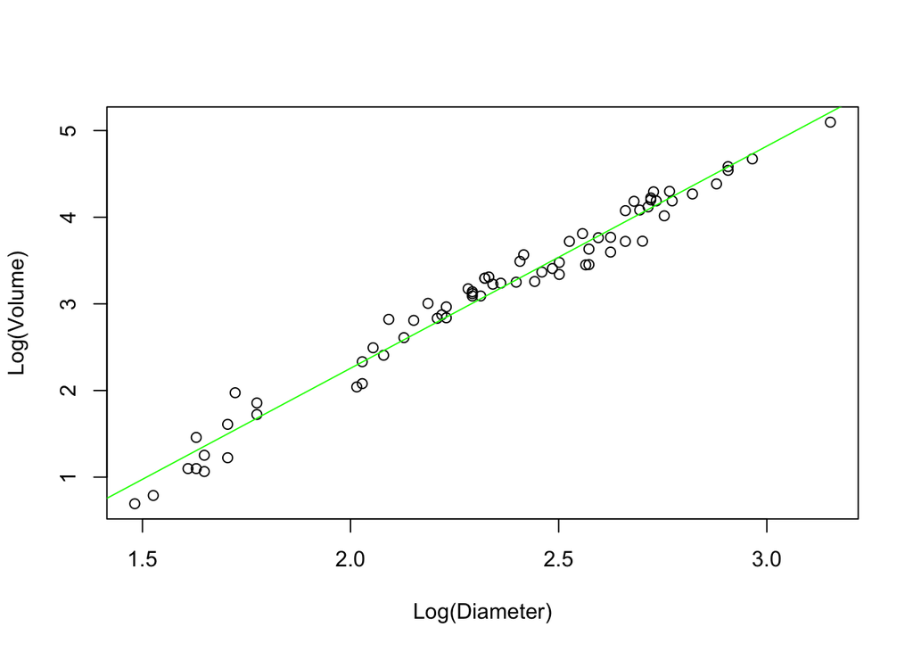

```r
plot(leaf2$lnDiam,leaf2$lnVol, xlab="Log(Diameter)",ylab="Log(Volume)" )
leaffit3=lm(leaf2$lnVol~leaf2$lnDiam)
abline(leaffit3, col="green")
```

9. Comment: From residual vs. fitted values, no evidence of departure from linearity since the dots are more randomly scattered around the line than the original plot.

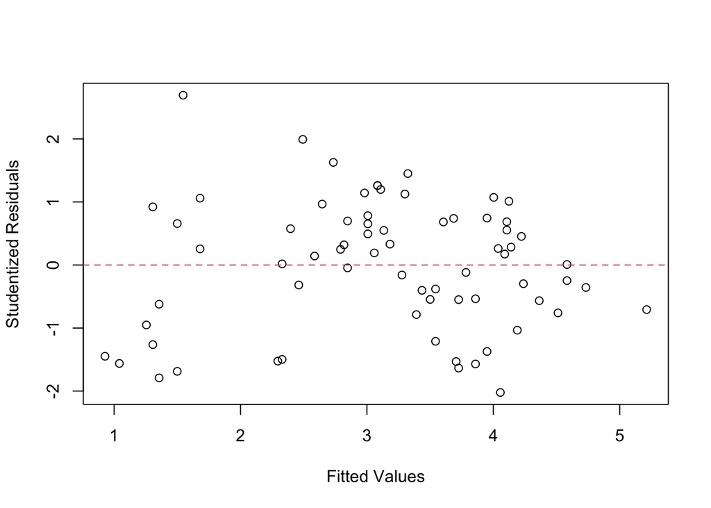

```r
plot(leaffit3$fitted.values,studres(leaffit3),ylab="Studentized Residuals",xlab="Fitted Values")
abline(h=0,col=2,lty=2)
```

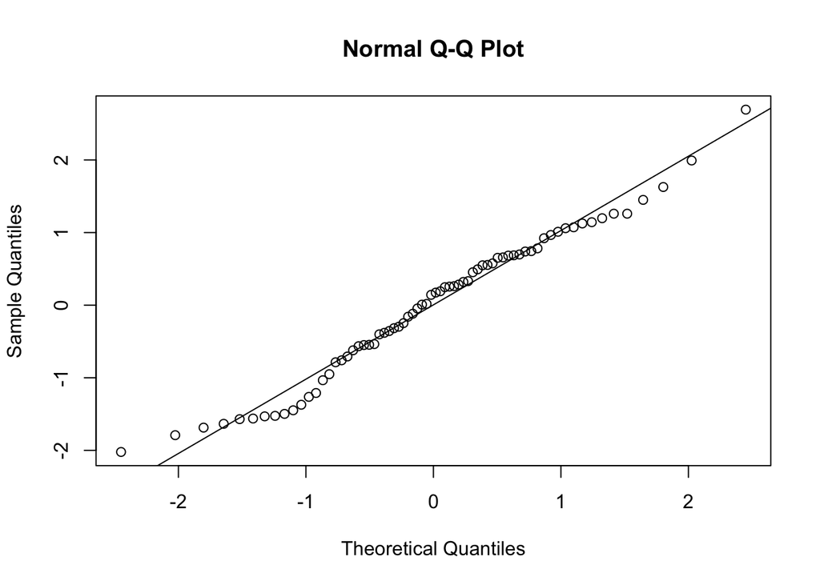

```r
qqnorm(studres(leaffit3))
qqline(studres(leaffit3))
```

Comment: From the AD test, we found that p-value for normality is 0.1815, which is greater than 0.05, which indicates the data are approximately normally distributed.

```r
ad.test(studres(leaffit3))
```

```
##
##  Anderson-Darling normality test
##
## data:  studres(leaffit3)
## A = 0.51871, p-value = 0.1815
```

Comment: From the Leverage plot, there are several points with leverage values higher than the expected cut-off. However, there are three points that have outstandingly large leverage values.

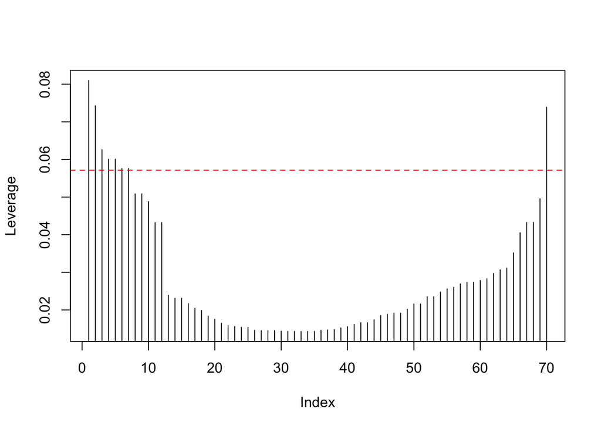

```r
plot(hatvalues(leaffit3), type="h", ylab="Leverage")
n=nrow(leaf2)
p=length(coefficients(leaffit3))
cutLev=2*p/n
abline(h=cutLev, col="red", lty=2)
```

24. The point with highest Cook’s distance is when diameter = 5.6, volume = 7.2

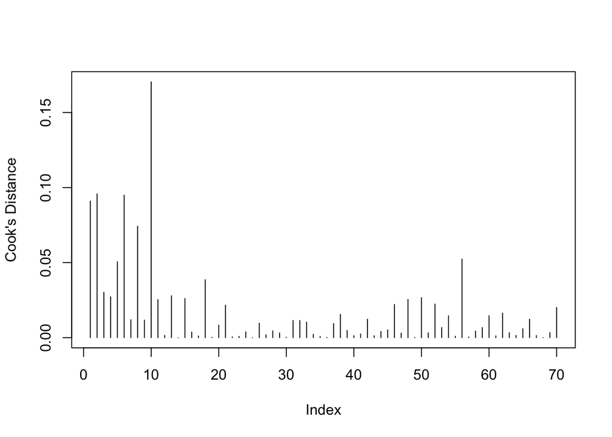

```r
plot(cooks.distance(leaffit3), ylab="Cook's Distance", type="h")
abline(h=1, col="red", lty=2)
```

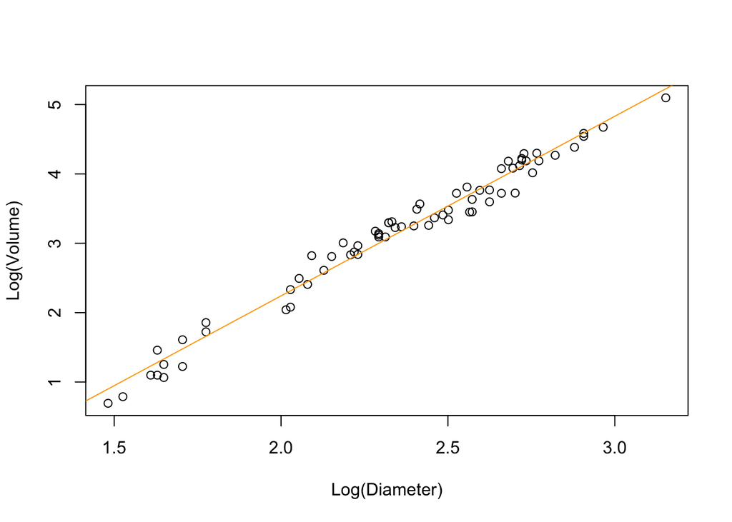

```r
newleaf=leaf2[-10,]
plot(newleaf$lnDiam,newleaf$lnVol, xlab="Log(Diameter)",ylab="Log(Volume)")
newleaffit=lm(lnVol~lnDiam, data=newleaf)
abline(newleaffit, col="orange")
```

Comment: From residual vs. fitted values, no evidence of departure from linearity since the dots are more randomly scattered around the line than the original plot.

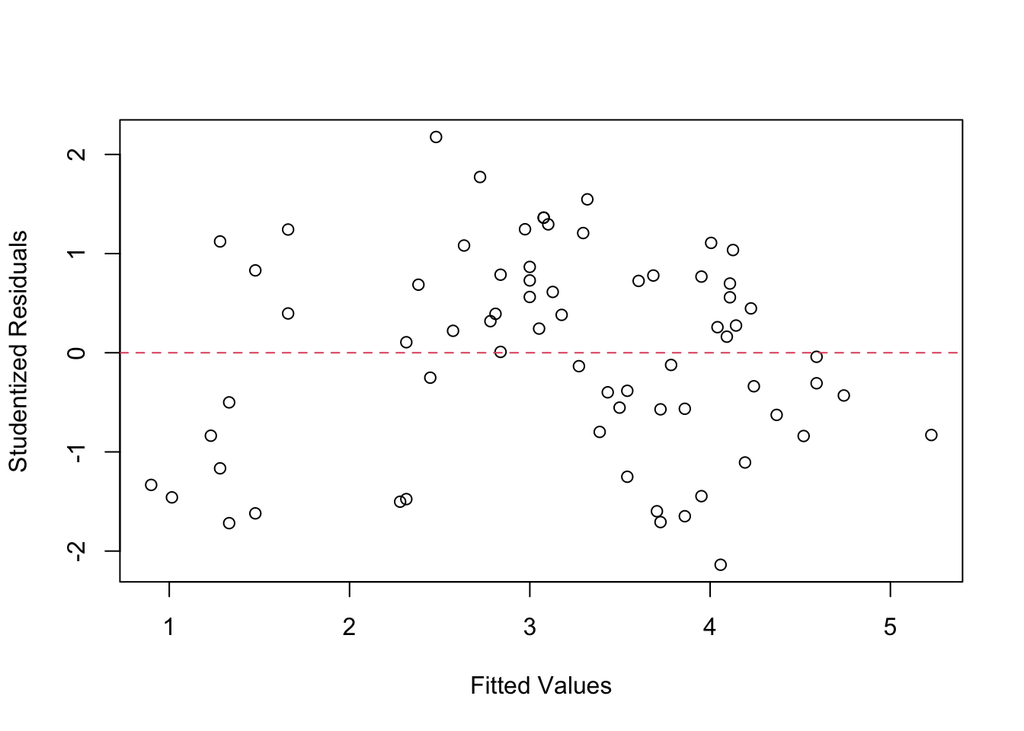

```r
plot(newleaffit$fitted.values,studres(newleaffit),ylab="Studentized Residuals",xlab="Fitted Values")
abline(h=0,col=2,lty=2)
```

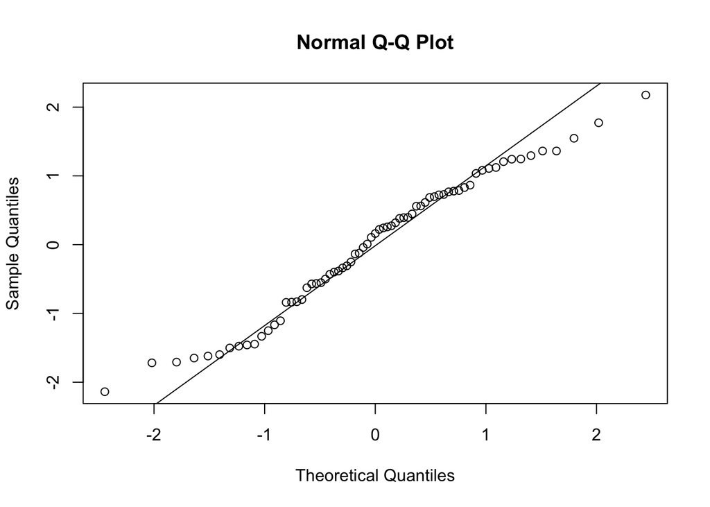

```r
qqnorm(studres(newleaffit))
qqline(studres(newleaffit))
```

Comment: From the AD test, we found that p-value for normality is 0.1036, which is greater than 0.05, which indicates the data are approximately normally distributed.

```r
ad.test(studres(newleaffit))
```

```
##
##  Anderson-Darling normality test
##
## data:  studres(newleaffit)
## A = 0.61808, p-value = 0.1036
```

11. $$\hat{log(Volume)}=-2.937+2.590*log(Diameter)$$
    The intercept is -2.937, which has no physical meaning because there is not negative value of volume when the diameter is 0. It is negative just because it is based on the least squared regression line. The slope is 2.590, which means for every 1 unit of log of diameter increases, the log of volume is predicted to increase 2.590 units.

```r
summary(newleaffit)
```

```
##
## Call:
## lm(formula = lnVol ~ lnDiam, data = newleaf)
##
## Residuals:
##      Min       1Q   Median       3Q      Max
## -0.33498 -0.12944  0.02625  0.12401  0.34144
##
## Coefficients:
##             Estimate Std. Error t value Pr(>|t|)
## (Intercept) -2.93706    0.11882  -24.72   <2e-16 ***
## lnDiam       2.58955    0.04987   51.92   <2e-16 ***
## ---
## Signif. codes:  0 '***' 0.001 '**' 0.01 '*' 0.05 '.' 0.1 ' ' 1
##
## Residual standard error: 0.1629 on 67 degrees of freedom
## Multiple R-squared:  0.9757, Adjusted R-squared:  0.9754
## F-statistic:  2696 on 1 and 67 DF,  p-value: < 2.2e-16
```